# Machine Learning Analysis of Human Activity

Lakshmy Priya

4 March 2016

## Introduction

The goal of this analysis is to predict the manner in which 6 participants performed a series of exercies. The classification is recorded as the “classe” variable in the training set and ranges from A to E, where A means the exercise was performed correctly, and each letter B-E specifies a certain common mistake. The final model chosen will be tested on 20 cases.

The data is sourced from http://groupware.les.inf.puc-rio.br/har

## Loading the data

The training data for this project are available here: https://d396qusza40orc.cloudfront.net/predmachlearn/pml-training.csv

The test data are available here: https://d396qusza40orc.cloudfront.net/predmachlearn/pml-testing.csv

```r
library(caret)
library(pamr)
library(rattle)
library(rpart)
library(randomForest)
library(foreach)
library(e1071)
```

```r
training <- read.csv("pml-training.csv", na.strings = c("NA",""))
testing <- read.csv("pml-testing.csv",na.strings = c("NA",""))
dim(training)
```

```
## [1] 19622   160
```

```r
summary(complete.cases(training))
```

```
##    Mode   FALSE    TRUE    NA's
## logical   19216     406       0
```

There are 160 variables in the original set. We will cut this down to the required variables as well as columns that do not contain a large amount of NAs

```r
## Removing near empty columns

cols <- NULL
for (i in 1:160){
cols[i] <- sum(is.na(training[i]))
}

training2 <- training[cols<19000]
summary(complete.cases(training2))
```

```
##    Mode    TRUE    NA's
## logical   19622       0
```

```r
## The first 7 columns are not predictors and contain timestamps, index, and participant names

final_train <- training2[8:60]
names <- names(final_train)
final_test <- testing[names[1:52]]
```

## Cross-validation

Partioning the final training set to a test and training set for the model prediction using random sampling into a 60-40 split.

Errors will be estimated on the test set.

```r
set.seed(1234)

inTrain <- createDataPartition(final_train$classe, p = 0.6, list = FALSE)
fTraining <- final_train[inTrain,]
fTesting <- final_train[-inTrain,]
dim(fTraining)
```

```
## [1] 11776    53
```

## Modelling

We will try a couple of methods and choose the final model with the best accuracy. Pre-processing methods were explored but did not improve accuracy.

1. Using rpart

This model gave poor accuracy results and is dismissed

```r
set.seed(2345)
modelrp <- train(classe~., data = fTraining, method = "rpart")
predictrp <- predict(modelrp, newdata = fTesting)
confusionMatrix(predictrp, fTesting$classe)
```

```
## Confusion Matrix and Statistics
##
##           Reference
## Prediction    A    B    C    D    E
##          A 2029  638  644  567  209
##          B   44  505   49  232  211
##          C  155  375  675  487  383
##          D    0    0    0    0    0
##          E    4    0    0    0  639
##
## Overall Statistics
##
##                Accuracy : 0.4904
##                  95% CI : (0.4793, 0.5016)
##     No Information Rate : 0.2845
##     P-Value [Acc > NIR] : < 2.2e-16
##
##                   Kappa : 0.3339
##  Mcnemar's Test P-Value : NA
##
## Statistics by Class:
##
##                      Class: A Class: B Class: C Class: D Class: E
## Sensitivity            0.9091  0.33267  0.49342   0.0000  0.44313
## Specificity            0.6334  0.91530  0.78388   1.0000  0.99938
## Pos Pred Value         0.4965  0.48511  0.32530      NaN  0.99378
## Neg Pred Value         0.9460  0.85114  0.87992   0.8361  0.88852
## Prevalence             0.2845  0.19347  0.17436   0.1639  0.18379
## Detection Rate         0.2586  0.06436  0.08603   0.0000  0.08144
## Detection Prevalence   0.5209  0.13268  0.26447   0.0000  0.08195
## Balanced Accuracy      0.7712  0.62399  0.63865   0.5000  0.72125
```

[figure not shown]

2. Using random forests

This model has high accuracy but is time-consuming. Processing time was limited using the traincontrol method and limiting the number of trees. The out-of-sample error is 100 - 98.9%, which is about 1.1% . Since the accuracy is quite high no other models were explored.

```r
set.seed(2345)
start <- proc.time()
fitControl <- trainControl(method = "cv", number = 3, allowParallel = T, verbose = F)
modelrf <- train(classe~., data = fTraining, method = "rf", ntree = 100, trControl = fitControl)
end <- proc.time()
lapsed <- start - end
lapsed
```

```
##    user  system elapsed
##  -58.27   -0.30  -58.73
```

```r
predictrf <- predict(modelrf, newdata = fTesting)
confusionMatrix(predictrf, fTesting$classe)
```

```
## Confusion Matrix and Statistics
##
##           Reference
## Prediction    A    B    C    D    E
##          A 2231   18    0    0    0
##          B    0 1494   13    1    4
##          C    1    6 1346   23    3
##          D    0    0    9 1260    2
##          E    0    0    0    2 1433
##
## Overall Statistics
##
##                Accuracy : 0.9895
##                  95% CI : (0.987, 0.9917)
##     No Information Rate : 0.2845
##     P-Value [Acc > NIR] : < 2.2e-16
##
##                   Kappa : 0.9868
##  Mcnemar's Test P-Value : NA
##
## Statistics by Class:
##
##                      Class: A Class: B Class: C Class: D Class: E
## Sensitivity            0.9996   0.9842   0.9839   0.9798   0.9938
## Specificity            0.9968   0.9972   0.9949   0.9983   0.9997
## Pos Pred Value         0.9920   0.9881   0.9761   0.9913   0.9986
## Neg Pred Value         0.9998   0.9962   0.9966   0.9960   0.9986
## Prevalence             0.2845   0.1935   0.1744   0.1639   0.1838
## Detection Rate         0.2843   0.1904   0.1716   0.1606   0.1826
## Detection Prevalence   0.2866   0.1927   0.1758   0.1620   0.1829
## Balanced Accuracy      0.9982   0.9907   0.9894   0.9891   0.9967
```

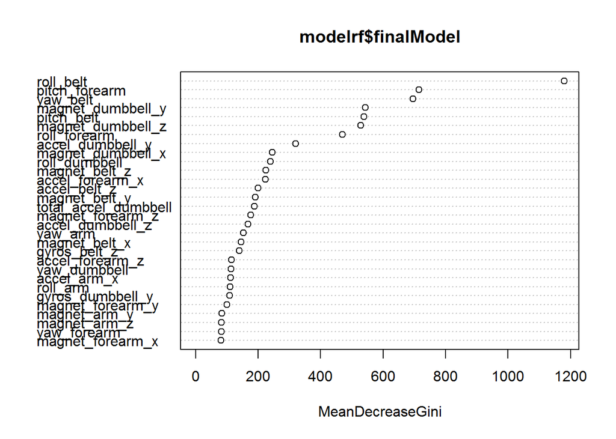

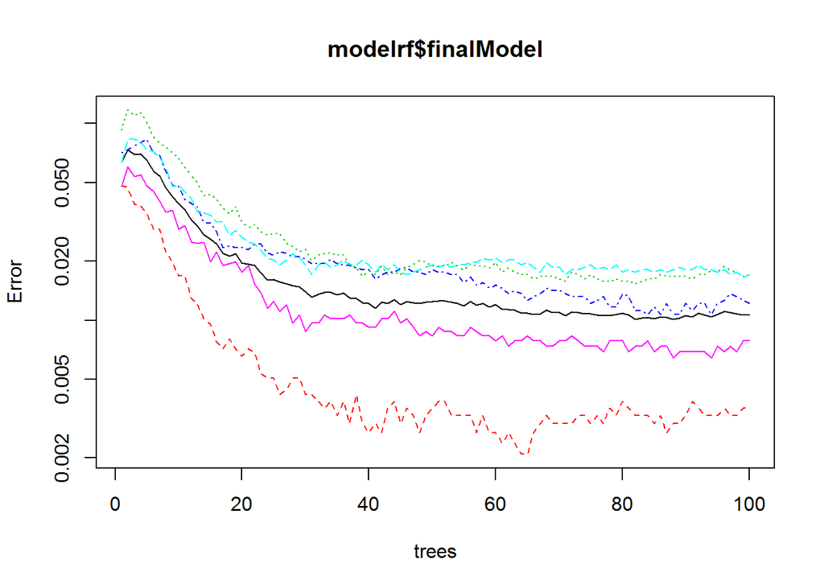

## Predictions on final 20 test cases

```r
predictfinal <- predict(modelrf, newdata = final_test)
predictfinal
```

```
##  [1] B A B A A E D B A A B C B A E E A B B B
## Levels: A B C D E
```

## Conclusion

The final model has high accuracy rates of around 99% which suggest the classification of the final 20 test cases is correct. The importance plot of the different predictors suggest that the roll belt measurements, the pitch forearm and the yaw belt have the highest impact on classifying the exercise. Future models could be built with just the top 10-20 predictors instead of the full set of 52 measurements with little loss in predictive ability.

## Notes

1. PCA reduction and other pre-processing methods were attempted but did not improve accuracy when applied to rpart.
2. Ntree is set to 100 and cv to 3 after multiple trials and errors to find the ideal timing to process the entire dataset.